# Supervised Learning: Regression Project 2 - Cars4U

### Median and Mean of Mileage data is approximately 18; therefore impute missing data for mileage with Median. Since distribution is not skewed; transform data with MinMax Transformation

```python
#Count the number of missing values per row
cars2.isnull().sum(axis=1).value_counts()
```

```
0    5871
1    1308
3      36
2      27
4      10
dtype: int64
```

```python
#Locate and Observe the rows where the Mileage2 data is NaN;
cars2[cars2['Mileage2'].isnull()]
```

|  | Location | Year | Kilometers_Driven | Fuel_Type | Transmission | Owner_Type | Engine | Power | Seats | New_Price | Price | brand_name | model_name | year_log | kilometer_driven_scale | Mileage2 |
| --- | --- | --- | --- | --- | --- | --- | --- | --- | --- | --- | --- | --- | --- | --- | --- | --- |
| 4446 | Chennai | 2016 | 50000 | Electric | Automatic | First | 72 CC | 41 bhp | 5.0 | 13.58 | 13.00 | Mahindra | E Verito D4 | 7.609367 | 0.064310 | NaN |
| 4904 | Mumbai | 2011 | 44000 | Electric | Automatic | First | 1798 CC | 73 bhp | 5.0 | 24.01 | 12.75 | Toyota | Prius 2009-2016 Z4 | 7.606885 | 0.056566 | NaN |

### Mileage2 is the only NaN value for these two rows therefore impute the missing values with the Median

```python
#Replace the Mileage2 NaN values with the Median
cars2['Mileage2'] = cars2['Mileage2'].fillna(cars2['Mileage2'].median())
```

```python
#Check for any remaining Null values in the Mileage column
cars2[cars2['Mileage2'].isnull()]
```

|  | Location | Year | Kilometers_Driven | Fuel_Type | Transmission | Owner_Type | Engine | Power | Seats | New_Price | Price | brand_name | model_name | year_log | kilometer_driven_scale | Mileage2 |
| --- | --- | --- | --- | --- | --- | --- | --- | --- | --- | --- | --- | --- | --- | --- | --- | --- |

```python
#apply min-max transformation to Mileage data since Data is not heavily skewed
cars2[['Mileage_scale']] = MinMaxScaler().fit_transform(cars2[['Mileage2']])
```

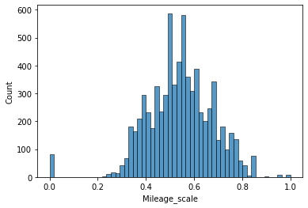

```python
#Observe distribution of scaled Mileage data
sns.histplot(data=cars2, x='Mileage_scale')
```

```python
#Split Mileage into Engine and Units
cars2[['Engine2','Eng_Units']] = cars2['Engine'].str.split(' ',1,expand=True)
cars2.head()
```

|  | Location | Year | Kilometers_Driven | Fuel_Type | Transmission | Owner_Type | Engine | Power | Seats | New_Price | Price | brand_name | model_name | year_log | kilometer_driven_scale | Mileage2 | Mileage_scale | Engine2 | Eng_Units |
| --- | --- | --- | --- | --- | --- | --- | --- | --- | --- | --- | --- | --- | --- | --- | --- | --- | --- | --- | --- |
| 0 | Mumbai | 2010 | 72000 | CNG | Manual | First | 998 CC | 58.16 bhp | 5.0 | 5.51 | 1.75 | Maruti | Wagon R LXI CNG | 7.606387 | 0.092703 | 26.60 | 0.793083 | 998 | CC |
| 1 | Pune | 2015 | 41000 | Diesel | Manual | First | 1582 CC | 126.2 bhp | 5.0 | 16.06 | 12.50 | Hyundai | Creta 1.6 CRDi SX Option | 7.608871 | 0.052694 | 19.67 | 0.586464 | 1582 | CC |
| 2 | Chennai | 2011 | 46000 | Petrol | Manual | First | 1199 CC | 88.7 bhp | 5.0 | 8.61 | 4.50 | Honda | Jazz V | 7.606885 | 0.059147 | 18.20 | 0.542636 | 1199 | CC |
| 3 | Chennai | 2012 | 87000 | Diesel | Manual | First | 1248 CC | 88.76 bhp | 7.0 | 11.27 | 6.00 | Maruti | Ertiga VDI | 7.607381 | 0.112062 | 20.77 | 0.619261 | 1248 | CC |
| 4 | Coimbatore | 2013 | 40670 | Diesel | Automatic | Second | 1968 CC | 140.8 bhp | 5.0 | 53.14 | 17.74 | Audi | A4 New 2.0 TDI Multitronic | 7.607878 | 0.052268 | 15.20 | 0.453190 | 1968 | CC |

```python
#Drop unnecessary columns after Engine column Split
cars2.drop(columns=['Engine','Eng_Units'], inplace = True)
```

```python
cars2.info()
```

```
<class 'pandas.core.frame.DataFrame'>
Int64Index: 7252 entries, 0 to 7252
Data columns (total 17 columns):
 #   Column                  Non-Null Count  Dtype
---  ------                  --------------  -----
 0   Location                7252 non-null   category
 1   Year                    7252 non-null   int64
 2   Kilometers_Driven       7252 non-null   int64
 3   Fuel_Type               7252 non-null   category
 4   Transmission            7252 non-null   category
 5   Owner_Type              7252 non-null   category
 6   Power                   7077 non-null   object
 7   Seats                   7199 non-null   float64
 8   New_Price               7252 non-null   float64
 9   Price                   6018 non-null   float64
 10  brand_name              7252 non-null   object
 11  model_name              7252 non-null   object
 12  year_log                7252 non-null   float64
 13  kilometer_driven_scale  7252 non-null   float64
 14  Mileage2                7252 non-null   float64
 15  Mileage_scale           7252 non-null   float64
 16  Engine2                 7206 non-null   object
dtypes: category(4), float64(7), int64(2), object(4)
memory usage: 822.4+ KB
```

```python
# Change Engine2 datatype to float
cars2['Engine2'] = cars2['Engine2'].astype('float64')
```

```python
#Locate and Observe the rows where the Engine2 data is NaN;
df = cars2[cars2['Engine2'].isnull()]
```

```python
# most rows don't have missing values now
num_missing = cars2.isnull().sum(axis=1)
num_missing.value_counts()
```

```
0    5873
1    1306
3      36
2      27
4      10
dtype: int64
```

### Rows containing missing Engine values also contain missing Seat values and missing Power values.

```python
#Code is from Data Preprocessing Haands - on Notebook; Locate missing Null values across multiple rows and columnsto confirm observation re:Engine, Seat, and Power columns
for n in num_missing.value_counts().sort_index().index:
    if n > 0:
        print(f'For the rows with exactly {n} missing values, NAs are found in:')
        n_miss_per_col = cars2[num_missing == n].isnull().sum()
        print(n_miss_per_col[n_miss_per_col > 0])
        print('\n\n')
```

```
For the rows with exactly 1 missing values, NAs are found in:
Power     103
Seats       2
Price    1201
dtype: int64



For the rows with exactly 2 missing values, NAs are found in:
Power    26
Seats     5
Price    23
dtype: int64



For the rows with exactly 3 missing values, NAs are found in:
Power      36
Seats      36
Engine2    36
dtype: int64



For the rows with exactly 4 missing values, NAs are found in:
Power      10
Seats      10
Price      10
Engine2    10
dtype: int64
```

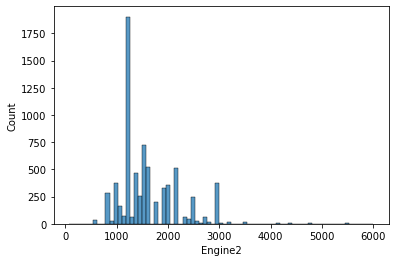

```python
sns.histplot(data=cars2, x='Engine2');
```

```python
cars2['Engine2'].describe()
```

```
count    7206.000000
mean     1616.382459
std       595.105530
min        72.000000
25%      1198.000000
50%      1493.000000
75%      1968.000000
max      5998.000000
Name: Engine2, dtype: float64
```

### For Engine data, Mean = 1616 and Median is 1493; Median will be used to impute values. Data will be transformed using MinMax scaling

```python
#Replace the Engine2 NaN values with the Median
cars2['Engine2'] = cars2['Engine2'].fillna(cars2['Engine2'].median())
```

```python
#Check for any remaining Null values in the Engine2 column
cars2[cars2['Engine2'].isnull()]
```

|  | Location | Year | Kilometers_Driven | Fuel_Type | Transmission | Owner_Type | Power | Seats | New_Price | Price | brand_name | model_name | year_log | kilometer_driven_scale | Mileage2 | Mileage_scale | Engine2 |
| --- | --- | --- | --- | --- | --- | --- | --- | --- | --- | --- | --- | --- | --- | --- | --- | --- | --- |

```python
#apply min-max transformation to Engine data since Data is not heavily skewed
cars2[['Engine_scale']] = MinMaxScaler().fit_transform(cars2[['Engine2']])
```

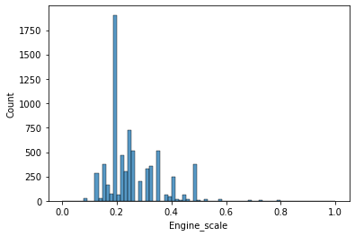

```python
#Verify Engine_scale Distribution
sns.histplot(data = cars2, x='Engine_scale');
```

```python
# Change Seats datatype to Category
cars2['Seats'] = cars2['Seats'].astype('category')
cars2.info()
```

```
<class 'pandas.core.frame.DataFrame'>
Int64Index: 7252 entries, 0 to 7252
Data columns (total 18 columns):
 #   Column                  Non-Null Count  Dtype
---  ------                  --------------  -----
 0   Location                7252 non-null   category
 1   Year                    7252 non-null   int64
 2   Kilometers_Driven       7252 non-null   int64
 3   Fuel_Type               7252 non-null   category
 4   Transmission            7252 non-null   category
 5   Owner_Type              7252 non-null   category
 6   Power                   7077 non-null   object
 7   Seats                   7199 non-null   category
 8   New_Price               7252 non-null   float64
 9   Price                   6018 non-null   float64
 10  brand_name              7252 non-null   object
 11  model_name              7252 non-null   object
 12  year_log                7252 non-null   float64
 13  kilometer_driven_scale  7252 non-null   float64
 14  Mileage2                7252 non-null   float64
 15  Mileage_scale           7252 non-null   float64
 16  Engine2                 7252 non-null   float64
 17  Engine_scale            7252 non-null   float64
dtypes: category(5), float64(8), int64(2), object(3)
memory usage: 829.9+ KB
```

```python
cars2['Seats'].value_counts()
```

```
5.0     6046
7.0      796
8.0      170
4.0      119
6.0       38
2.0       18
10.0       8
9.0        3
0.0        1
Name: Seats, dtype: int64
```

```python
#Replace the seats NaN values with the Mode
cars2['Seats'].fillna(5.0, inplace=True)
cars2['Seats'].value_counts()
```

```
5.0     6099
7.0      796
8.0      170
4.0      119
6.0       38
2.0       18
10.0       8
9.0        3
0.0        1
Name: Seats, dtype: int64
```

```python
#Check for Null values in Seats
cars2[cars2['Seats'].isnull()]
```

|  | Location | Year | Kilometers_Driven | Fuel_Type | Transmission | Owner_Type | Power | Seats | New_Price | Price | brand_name | model_name | year_log | kilometer_driven_scale | Mileage2 | Mileage_scale | Engine2 | Engine_scale |
| --- | --- | --- | --- | --- | --- | --- | --- | --- | --- | --- | --- | --- | --- | --- | --- | --- | --- | --- |

## Seats: Investigate Seat = 0, an unreasonable value for seats; replace value with Median

```python
cars2['Seats']=cars2['Seats'].replace(0.0,cars['Seats'].median())
cars2['Seats'].value_counts()
```

```
5.0     6100
7.0      796
8.0      170
4.0      119
6.0       38
2.0       18
10.0       8
9.0        3
Name: Seats, dtype: int64
```

```python
#Split Power into Power and Units
cars2[['Power2','P_Units']] = cars2['Power'].str.split(' ',1,expand=True)
```

```python
#Drop unnecessary columns after Power column Split
cars2.drop(columns=['Power','P_Units'], inplace = True)
```

```python
# Change Power2 datatype to float
cars2['Power2'] = cars2['Power2'].astype('float64')
```

```python
cars2.info()
```

```
<class 'pandas.core.frame.DataFrame'>
Int64Index: 7252 entries, 0 to 7252
Data columns (total 18 columns):
 #   Column                  Non-Null Count  Dtype
---  ------                  --------------  -----
 0   Location                7252 non-null   category
 1   Year                    7252 non-null   int64
 2   Kilometers_Driven       7252 non-null   int64
 3   Fuel_Type               7252 non-null   category
 4   Transmission            7252 non-null   category
 5   Owner_Type              7252 non-null   category
 6   Seats                   7252 non-null   category
 7   New_Price               7252 non-null   float64
 8   Price                   6018 non-null   float64
 9   brand_name              7252 non-null   object
 10  model_name              7252 non-null   object
 11  year_log                7252 non-null   float64
 12  kilometer_driven_scale  7252 non-null   float64
 13  Mileage2                7252 non-null   float64
 14  Mileage_scale           7252 non-null   float64
 15  Engine2                 7252 non-null   float64
 16  Engine_scale            7252 non-null   float64
 17  Power2                  7077 non-null   float64
dtypes: category(5), float64(9), int64(2), object(2)
memory usage: 829.8+ KB
```

```python
#Check for location of Null values in Power
cars2[cars2['Power2'].isnull()]
```

|  | Location | Year | Kilometers_Driven | Fuel_Type | Transmission | Owner_Type | Seats | New_Price | Price | brand_name | model_name | year_log | kilometer_driven_scale | Mileage2 | Mileage_scale | Engine2 | Engine_scale | Power2 |
| --- | --- | --- | --- | --- | --- | --- | --- | --- | --- | --- | --- | --- | --- | --- | --- | --- | --- | --- |
| 76 | Jaipur | 2008 | 111111 | Diesel | Manual | First | 5.0 | 11.685 | 2.00 | Ford | Fiesta 1.4 SXi TDCi | 7.605392 | 0.143180 | 17.80 | 0.530710 | 1399.0 | 0.223928 | NaN |
| 79 | Hyderabad | 2005 | 87591 | Petrol | Manual | First | 5.0 | 4.550 | 1.30 | Hyundai | Santro Xing XL | 7.603898 | 0.112825 | 0.00 | 0.000000 | 1086.0 | 0.171110 | NaN |
| 89 | Hyderabad | 2007 | 73745 | Petrol | Manual | First | 5.0 | 4.550 | 2.10 | Hyundai | Santro Xing XO | 7.604894 | 0.094955 | 17.00 | 0.506857 | 1086.0 | 0.171110 | NaN |
| 120 | Mumbai | 2005 | 102000 | Petrol | Manual | Second | 5.0 | 4.550 | 0.85 | Hyundai | Santro Xing XL eRLX Euro III | 7.603898 | 0.131421 | 17.00 | 0.506857 | 1086.0 | 0.171110 | NaN |
| 143 | Kochi | 2008 | 80759 | Petrol | Manual | Third | 5.0 | 4.550 | 1.67 | Hyundai | Santro Xing XO eRLX Euro II | 7.605392 | 0.104007 | 17.00 | 0.506857 | 1086.0 | 0.171110 | NaN |
| 194 | Ahmedabad | 2007 | 60006 | Petrol | Manual | First | 5.0 | 13.580 | 2.95 | Honda | City 1.5 GXI | 7.604894 | 0.077223 | 0.00 | 0.000000 | 1493.0 | 0.239791 | NaN |
| 208 | Kolkata | 2010 | 42001 | Petrol | Manual | First | 5.0 | 7.880 | 2.11 | Maruti | Swift 1.3 VXi | 7.606387 | 0.053986 | 16.10 | 0.480024 | 1493.0 | 0.239791 | NaN |
| 227 | Delhi | 2013 | 47000 | Diesel | Manual | First | 5.0 | 7.880 | 4.10 | Maruti | Swift VDI BSIV | 7.607878 | 0.060438 | 17.80 | 0.530710 | 1248.0 | 0.198448 | NaN |
| 245 | Mumbai | 2007 | 72000 | Petrol | Manual | Third | 5.0 | 4.550 | 0.95 | Hyundai | Santro Xing XO eRLX Euro II | 7.604894 | 0.092703 | 17.00 | 0.506857 | 1086.0 | 0.171110 | NaN |
| 262 | Hyderabad | 2006 | 99000 | Petrol | Manual | First | 5.0 | 4.550 | 1.75 | Hyundai | Santro Xing XL | 7.604396 | 0.127549 | 0.00 | 0.000000 | 1086.0 | 0.171110 | NaN |
| 307 | Chennai | 2006 | 58000 | Petrol | Manual | Second | 5.0 | 4.550 | 1.50 | Hyundai | Santro Xing XL | 7.604396 | 0.074635 | 0.00 | 0.000000 | 1086.0 | 0.171110 | NaN |
| 308 | Kolkata | 2011 | 60020 | Diesel | Manual | First | 5.0 | 7.880 | 2.50 | Maruti | Swift VDI BSIV | 7.606885 | 0.077242 | 17.80 | 0.530710 | 1248.0 | 0.198448 | NaN |
| 386 | Hyderabad | 2007 | 50958 | Petrol | Manual | First | 5.0 | 4.550 | 1.95 | Hyundai | Santro Xing XL eRLX Euro III | 7.604894 | 0.065546 | 17.00 | 0.506857 | 1086.0 | 0.171110 | NaN |
| 424 | Hyderabad | 2010 | 42021 | Diesel | Manual | First | 5.0 | 10.150 | 5.45 | Volkswagen | Jetta 2007-2011 1.9 L TDI | 7.606387 | 0.054012 | 0.00 | 0.000000 | 1968.0 | 0.319946 | NaN |
| 428 | Pune | 2006 | 108000 | Petrol | Manual | Second | 5.0 | 4.550 | 1.20 | Hyundai | Santro Xing XO eRLX Euro II | 7.604396 | 0.139165 | 17.00 | 0.506857 | 1086.0 | 0.171110 | NaN |
| 443 | Coimbatore | 2012 | 50243 | Petrol | Manual | First | 5.0 | 4.550 | 3.35 | Hyundai | Santro GLS I - Euro I | 7.607381 | 0.064623 | 0.00 | 0.000000 | 1086.0 | 0.171110 | NaN |
| 472 | Chennai | 2009 | 80524 | Petrol | Manual | Second | 5.0 | 11.685 | 2.50 | Ford | Fiesta 1.6 SXI ABS Duratec | 7.605890 | 0.103704 | 15.30 | 0.456172 | 1596.0 | 0.257172 | NaN |
| 575 | Chennai | 2006 | 83072 | Petrol | Manual | First | 5.0 | 4.550 | 1.40 | Hyundai | Santro Xing XO | 7.604396 | 0.106993 | 17.00 | 0.506857 | 1086.0 | 0.171110 | NaN |
| 631 | Chennai | 2002 | 70000 | Petrol | Manual | Third | 5.0 | 4.550 | 0.65 | Hyundai | Santro LS zipPlus | 7.602401 | 0.090122 | 0.00 | 0.000000 | 1086.0 | 0.171110 | NaN |
| 647 | Jaipur | 2004 | 200000 | Petrol | Manual | First | 5.0 | 4.550 | 0.80 | Hyundai | Santro Xing XP | 7.603399 | 0.257901 | 0.00 | 0.000000 | 1086.0 | 0.171110 | NaN |
| 648 | Jaipur | 2009 | 82000 | Diesel | Manual | Second | 5.0 | 7.630 | 0.75 | Tata | Indica DLS | 7.605890 | 0.105609 | 13.50 | 0.402504 | 1405.0 | 0.224941 | NaN |
| 733 | Chennai | 2006 | 97800 | Petrol | Manual | Third | 5.0 | 7.880 | 1.75 | Maruti | Swift 1.3 VXi | 7.604396 | 0.126001 | 16.10 | 0.480024 | 1493.0 | 0.239791 | NaN |
| 739 | Bangalore | 2007 | 60000 | Diesel | Manual | Second | 5.0 | 7.880 | 3.40 | Maruti | Swift VDI BSIV | 7.604894 | 0.077216 | 17.80 | 0.530710 | 1248.0 | 0.198448 | NaN |
| 748 | Hyderabad | 2007 | 71297 | Petrol | Manual | First | 5.0 | 4.550 | 2.20 | Hyundai | Santro Xing XO | 7.604894 | 0.091796 | 17.00 | 0.506857 | 1086.0 | 0.171110 | NaN |
| 749 | Mumbai | 2008 | 55001 | Diesel | Automatic | Second | 5.0 | 120.000 | 26.50 | Land | Rover Range Rover 3.0 D | 7.605392 | 0.070764 | 0.00 | 0.000000 | 1493.0 | 0.239791 | NaN |
| 829 | Mumbai | 2012 | 29605 | Petrol | Manual | First | 5.0 | 8.525 | 2.44 | Toyota | Etios Liva G | 7.607381 | 0.037988 | 18.30 | 0.545617 | 1197.0 | 0.189841 | NaN |
| 915 | Pune | 2008 | 103000 | Diesel | Automatic | Second | 2.0 | 11.300 | 3.00 | Smart | Fortwo CDI AT | 7.605392 | 0.132712 | 0.00 | 0.000000 | 799.0 | 0.122680 | NaN |
| 926 | Hyderabad | 2010 | 10000 | Petrol | Manual | First | 2.0 | 136.000 | 40.00 | Porsche | Cayman 2009-2012 S | 7.606387 | 0.012685 | 9.00 | 0.268336 | 3436.0 | 0.567668 | NaN |
| 934 | Kolkata | 2012 | 60000 | Diesel | Manual | First | 5.0 | 8.525 | 2.95 | Toyota | Etios GD | 7.607381 | 0.077216 | 23.59 | 0.703339 | 1364.0 | 0.218022 | NaN |
| 1068 | Pune | 2012 | 225000 | Diesel | Manual | Second | 5.0 | 8.525 | 2.60 | Toyota | Etios Liva GD | 7.607381 | 0.290166 | 23.59 | 0.703339 | 1364.0 | 0.218022 | NaN |

[output cut: 145 more lines]

```python
cars2['Power2'].describe()
```

```
count    7077.000000
mean      112.744692
std        53.469461
min        34.200000
25%        75.000000
50%        94.000000
75%       138.100000
max       616.000000
Name: Power2, dtype: float64
```

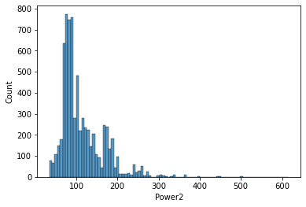

```python
sns.histplot(data=cars2, x='Power2')
```

### PowerData is skewed right therefore impute the missing Power data with the Median, 94.

```python
#Replace the Power2 NaN values with the Median
cars2['Power2'] = cars2['Power2'].fillna(cars2['Power2'].median())
```

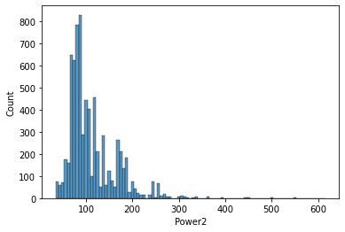

```python
sns.histplot(data=cars2, x='Power2')
```

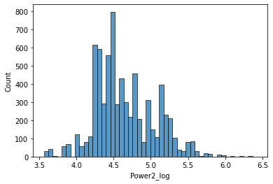

```python
# Apply log transformation to Power2 daa; check distribution of year_log
cars2["Power2_log"] = np.log(cars2["Power2"] + 1)
sns.histplot(data=cars2, x='Power2_log')
```

```python
#Check for Null values in Price, Target Variable
cars2[cars2['Price'].isnull()]
```

|  | Location | Year | Kilometers_Driven | Fuel_Type | Transmission | Owner_Type | Seats | New_Price | Price | brand_name | model_name | year_log | kilometer_driven_scale | Mileage2 | Mileage_scale | Engine2 | Engine_scale | Power2 | Power2_log |
| --- | --- | --- | --- | --- | --- | --- | --- | --- | --- | --- | --- | --- | --- | --- | --- | --- | --- | --- | --- |
| 6019 | Delhi | 2014 | 40929 | CNG | Manual | First | 4.0 | 4.360 | NaN | Maruti | Alto K10 LXI CNG | 7.608374 | 0.052603 | 32.26 | 0.961837 | 998.0 | 0.156261 | 58.20 | 4.080922 |
| 6020 | Coimbatore | 2013 | 54493 | Petrol | Manual | Second | 5.0 | 4.360 | NaN | Maruti | Alto 800 2016-2019 LXI | 7.607878 | 0.070108 | 24.70 | 0.736434 | 796.0 | 0.122173 | 47.30 | 3.877432 |
| 6021 | Mumbai | 2017 | 34000 | Diesel | Manual | First | 7.0 | 25.270 | NaN | Toyota | Innova Crysta Touring Sport 2.4 MT | 7.609862 | 0.043660 | 13.68 | 0.407871 | 2393.0 | 0.391664 | 147.80 | 5.002603 |
| 6022 | Hyderabad | 2012 | 139000 | Diesel | Manual | First | 5.0 | 8.525 | NaN | Toyota | Etios Liva GD | 7.607381 | 0.179174 | 23.59 | 0.703339 | 1364.0 | 0.218022 | 94.00 | 4.553877 |
| 6023 | Mumbai | 2014 | 29000 | Petrol | Manual | First | 5.0 | 10.250 | NaN | Hyundai | i20 Magna | 7.608374 | 0.037207 | 18.50 | 0.551580 | 1197.0 | 0.189841 | 82.85 | 4.429029 |
| ... | ... | ... | ... | ... | ... | ... | ... | ... | ... | ... | ... | ... | ... | ... | ... | ... | ... | ... | ... |
| 7248 | Hyderabad | 2011 | 89411 | Diesel | Manual | First | 5.0 | 13.230 | NaN | Volkswagen | Vento Diesel Trendline | 7.606885 | 0.115174 | 20.54 | 0.612403 | 1598.0 | 0.257509 | 103.60 | 4.650144 |
| 7249 | Mumbai | 2015 | 59000 | Petrol | Automatic | First | 5.0 | 10.150 | NaN | Volkswagen | Polo GT TSI | 7.608871 | 0.075925 | 17.21 | 0.513119 | 1197.0 | 0.189841 | 103.60 | 4.650144 |
| 7250 | Kolkata | 2012 | 28000 | Diesel | Manual | First | 5.0 | 9.470 | NaN | Nissan | Micra Diesel XV | 7.607381 | 0.035916 | 23.08 | 0.688134 | 1461.0 | 0.234391 | 63.10 | 4.160444 |
| 7251 | Pune | 2013 | 52262 | Petrol | Automatic | Third | 5.0 | 10.150 | NaN | Volkswagen | Polo GT TSI | 7.607878 | 0.067229 | 17.20 | 0.512821 | 1197.0 | 0.189841 | 103.60 | 4.650144 |
| 7252 | Kochi | 2014 | 72443 | Diesel | Automatic | First | 5.0 | 86.970 | NaN | Mercedes-Benz | E-Class 2009-2013 E 220 CDI Avantgarde | 7.608374 | 0.093275 | 10.00 | 0.298151 | 2148.0 | 0.350321 | 170.00 | 5.141664 |

1234 rows × 19 columns

```python
#Drop the rows in the cars2 dataset where the Price in NaN
cars2 = cars2[cars2['Price'].notna()]
```

```python
cars2.info()
```

```
<class 'pandas.core.frame.DataFrame'>
Int64Index: 6018 entries, 0 to 6018
Data columns (total 19 columns):
 #   Column                  Non-Null Count  Dtype
---  ------                  --------------  -----
 0   Location                6018 non-null   category
 1   Year                    6018 non-null   int64
 2   Kilometers_Driven       6018 non-null   int64
 3   Fuel_Type               6018 non-null   category
 4   Transmission            6018 non-null   category
 5   Owner_Type              6018 non-null   category
 6   Seats                   6018 non-null   category
 7   New_Price               6018 non-null   float64
 8   Price                   6018 non-null   float64
 9   brand_name              6018 non-null   object
 10  model_name              6018 non-null   object
 11  year_log                6018 non-null   float64
 12  kilometer_driven_scale  6018 non-null   float64
 13  Mileage2                6018 non-null   float64
 14  Mileage_scale           6018 non-null   float64
 15  Engine2                 6018 non-null   float64
 16  Engine_scale            6018 non-null   float64
 17  Power2                  6018 non-null   float64
 18  Power2_log              6018 non-null   float64
dtypes: category(5), float64(10), int64(2), object(2)
memory usage: 735.9+ KB
```

```python
cars2['brand_name'].value_counts()
```

```
Maruti           1211
Hyundai          1107
Honda             608
Toyota            411
Mercedes-Benz     318
Volkswagen        315
Ford              300
Mahindra          272
BMW               266
Audi              236
Tata              186
Skoda             173
Renault           145
Chevrolet         121
Nissan             91
Land               60
Jaguar             40
Fiat               28
Mitsubishi         27
Mini               26
Volvo              21
Porsche            18
Jeep               15
Datsun             13
Force               3
ISUZU               2
Isuzu               1
Smart               1
Bentley             1
Lamborghini         1
Ambassador          1
Name: brand_name, dtype: int64
```

```python
cars2['model_name'].value_counts()
```

```
XUV500 W8 2WD                       49
Swift VDI                           45
Swift Dzire VDI                     34
City 1.5 S MT                       34
Swift VDI BSIV                      31
                                    ..
Aspire Titanium Plus Diesel          1
Alto LX BSIII                        1
Renault Logan 1.4 GLX Petrol         1
Octavia Ambition Plus 2.0 TDI AT     1
Endeavour Hurricane LE               1
Name: model_name, Length: 1876, dtype: int64
```

## PreProcess Data for ML Model Build

```python
# Split data frame into dependent variable (y) and Independent Variables(X)
y = cars2["Price"]
X = cars2.drop(["Price"], axis=1)
```

```python
X = pd.get_dummies(
    X,
    columns=X.select_dtypes(include=["category","object"]).columns.tolist(),
    drop_first=True,
)

X.head()
```

|  | Year | Kilometers_Driven | New_Price | year_log | kilometer_driven_scale | Mileage2 | Mileage_scale | Engine2 | Engine_scale | Power2 | Power2_log | Location_Bangalore | Location_Chennai | Location_Coimbatore | Location_Delhi | Location_Hyderabad | Location_Jaipur | Location_Kochi | Location_Kolkata | Location_Mumbai | Location_Pune | Fuel_Type_Diesel | Fuel_Type_Electric | Fuel_Type_LPG | Fuel_Type_Petrol | Transmission_Manual | Owner_Type_Fourth & Above | Owner_Type_Second | Owner_Type_Third | … |
| --- | --- | --- | --- | --- | --- | --- | --- | --- | --- | --- | --- | --- | --- | --- | --- | --- | --- | --- | --- | --- | --- | --- | --- | --- | --- | --- | --- | --- | --- | --- |
| 0 | 2010 | 72000 | 5.51 | 7.606387 | 0.092703 | 26.60 | 0.793083 | 998.0 | 0.156261 | 58.16 | 4.080246 | 0 | 0 | 0 | 0 | 0 | 0 | 0 | 0 | 1 | 0 | 0 | 0 | 0 | 0 | 1 | 0 | 0 | 0 | … |
| 1 | 2015 | 41000 | 16.06 | 7.608871 | 0.052694 | 19.67 | 0.586464 | 1582.0 | 0.254809 | 126.20 | 4.845761 | 0 | 0 | 0 | 0 | 0 | 0 | 0 | 0 | 0 | 1 | 1 | 0 | 0 | 0 | 1 | 0 | 0 | 0 | … |
| 2 | 2011 | 46000 | 8.61 | 7.606885 | 0.059147 | 18.20 | 0.542636 | 1199.0 | 0.190179 | 88.70 | 4.496471 | 0 | 1 | 0 | 0 | 0 | 0 | 0 | 0 | 0 | 0 | 0 | 0 | 0 | 1 | 1 | 0 | 0 | 0 | … |
| 3 | 2012 | 87000 | 11.27 | 7.607381 | 0.112062 | 20.77 | 0.619261 | 1248.0 | 0.198448 | 88.76 | 4.497139 | 0 | 1 | 0 | 0 | 0 | 0 | 0 | 0 | 0 | 0 | 1 | 0 | 0 | 0 | 1 | 0 | 0 | 0 | … |
| 4 | 2013 | 40670 | 53.14 | 7.607878 | 0.052268 | 15.20 | 0.453190 | 1968.0 | 0.319946 | 140.80 | 4.954418 | 0 | 0 | 1 | 0 | 0 | 0 | 0 | 0 | 0 | 0 | 1 | 0 | 0 | 0 | 0 | 0 | 1 | 0 | … |

```python
X.info()
```

```
<class 'pandas.core.frame.DataFrame'>
Int64Index: 6018 entries, 0 to 6018
Columns: 1941 entries, Year to model_name_redi-GO T Option
dtypes: float64(9), int64(2), uint8(1930)
memory usage: 11.6 MB
```

```python
X_copy=X.copy()
```

```python
#Drop unnecessary columns after data scales
X.drop(columns=['Mileage2','Power2','Engine2','Year','Kilometers_Driven'], inplace = True)
```

```python
X.info()
```

```
<class 'pandas.core.frame.DataFrame'>
Int64Index: 6018 entries, 0 to 6018
Columns: 1936 entries, New_Price to model_name_redi-GO T Option
dtypes: float64(6), uint8(1930)
memory usage: 11.4 MB
```

## Outlier Treatment

### Explore Outliers for Numerical data (using code from Pre-Processing data videos that Identifies Outliers by comparing valeus to the IQR)

```python
quartiles = np.quantile(cars2['Year'][cars2['Year'].notnull()], [.25, .75])
year_4iqr = 4 * (quartiles[1] - quartiles[0])
print(f'Q1 = {quartiles[0]}, Q3 = {quartiles[1]}, 4*IQR = {year_4iqr}')
outlier_powers = cars2.loc[np.abs(cars2['Year'] - cars2['Year'].median()) > year_4iqr, 'Year']
outlier_powers
```

```
Q1 = 2011.0, Q3 = 2016.0, 4*IQR = 20.0
```

```
Series([], Name: Year, dtype: int64)
```

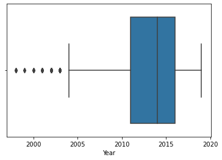

```python
sns.boxplot(data=cars2, x='Year')
```

```python
quartiles = np.quantile(cars2['Kilometers_Driven'][cars2['Kilometers_Driven'].notnull()], [.25, .75])
Kilometers_Driven_4iqr = 4 * (quartiles[1] - quartiles[0])
print(f'Q1 = {quartiles[0]}, Q3 = {quartiles[1]}, 4*IQR = {Kilometers_Driven_4iqr}')
outlier_KD = cars2.loc[np.abs(cars2['Kilometers_Driven'] - cars2['Kilometers_Driven'].median()) > Kilometers_Driven_4iqr, 'Kilometers_Driven']
outlier_KD
```

```
Q1 = 34000.0, Q3 = 73000.0, 4*IQR = 156000.0
```

```
29      262000
77      230000
181     216000
340     775000
358     620000
838     215000
1068    225000
1101    248000
1442    231673
1528    299322
1766    220000
1846    255000
1860    720000
1975    282000
2267    215750
2346    234000
2823    480000
2988    240000
3092    480000
3649    300000
3713    232000
3894    250000
4491    445000
4719    250000
4792    242000
5647    227000
5800    210000
5834    250000
Name: Kilometers_Driven, dtype: int64
```

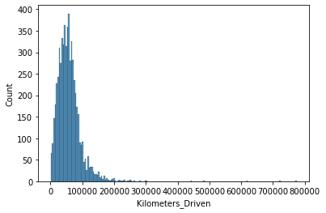

```python
sns.histplot(data=cars2, x='Kilometers_Driven')
```

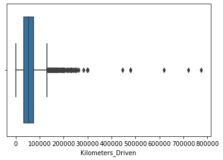

```python
sns.boxplot(data=cars2, x='Kilometers_Driven')
```

### Kilometers_Drive has a skewed right distribution therefore outliers appear to be reasonable for the distribution and problem domain.

```python
quartiles = np.quantile(cars2['New_Price'][cars2['New_Price'].notnull()], [.25, .75])
New_Price_4iqr = 4 * (quartiles[1] - quartiles[0])
print(f'Q1 = {quartiles[0]}, Q3 = {quartiles[1]}, 4*IQR = {New_Price_4iqr}')
outlier_NP = cars2.loc[np.abs(cars2['New_Price'] - cars2['New_Price'].median()) > New_Price_4iqr, 'New_Price']
outlier_NP
```

```
Q1 = 7.88, Q3 = 21.77, 4*IQR = 55.56
```

```
13      120.000
14      120.000
22       67.100
33       67.100
70      136.000
         ...
5921     86.970
5946     67.870
5996     69.675
6001     67.100
6008    136.000
Name: New_Price, Length: 400, dtype: float64
```

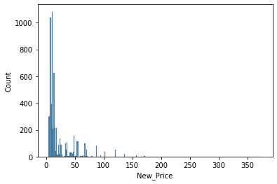

```python
sns.histplot(data=cars2, x='New_Price')
```

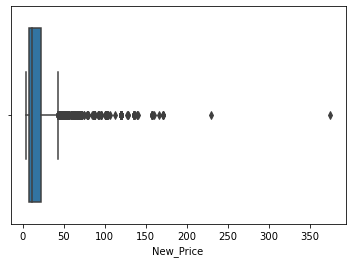

```python
sns.boxplot(data=cars2, x='New_Price')
```

### New_Price has a skewed right distribution therefore outliers appear to be reasonable for the distribution and problem domain.

```python
quartiles = np.quantile(cars2['Mileage2'][cars2['Mileage2'].notnull()], [.25, .75])
Mileage2_4iqr = 4 * (quartiles[1] - quartiles[0])
print(f'Q1 = {quartiles[0]}, Q3 = {quartiles[1]}, 4*IQR = {Mileage2_4iqr}')
outlier_Mileage = cars2.loc[np.abs(cars2['Mileage2'] - cars2['Mileage2'].median()) > Mileage2_4iqr, 'Mileage2']
outlier_Mileage
```

```
Q1 = 15.17, Q3 = 21.1, 4*IQR = 23.720000000000006
```

```
Series([], Name: Mileage2, dtype: float64)
```

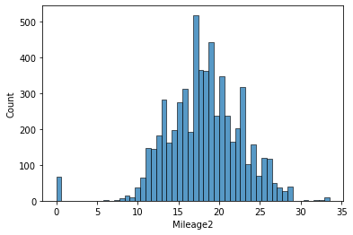

```python
sns.histplot(data=cars2, x='Mileage2')
```

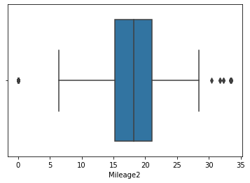

```python
sns.boxplot(data=cars2, x='Mileage2')
```

### Mileage has a somewhat distribution therefore outliers appear to be reasonable for the distribution and problem domain.NOTE:Previously, the median had been imputed to. unreasonable values

```python
quartiles = np.quantile(cars2['Engine2'][cars2['Engine2'].notnull()], [.25, .75])
Engine2_4iqr = 4 * (quartiles[1] - quartiles[0])
print(f'Q1 = {quartiles[0]}, Q3 = {quartiles[1]}, 4*IQR = {Engine2_4iqr}')
outlier_Engine2 = cars2.loc[np.abs(cars2['Engine2'] - cars2['Engine2'].median()) > Engine2_4iqr, 'Engine2']
outlier_Engine2
```

```
Q1 = 1198.0, Q3 = 1969.0, 4*IQR = 3084.0
```

```
70      4806.0
152     5461.0
2100    4806.0
2978    4806.0
4451    4951.0
4691    5461.0
4722    5461.0
5088    5000.0
5521    5998.0
5603    4806.0
5781    5204.0
5919    5000.0
Name: Engine2, dtype: float64
```

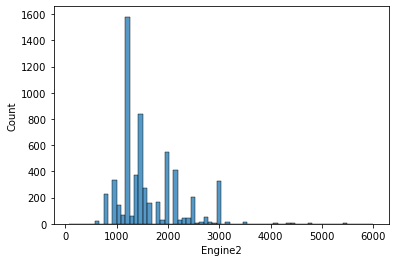

```python
sns.histplot(data=cars2, x='Engine2')
```

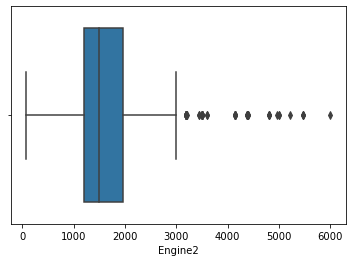

```python
sns.boxplot(data=cars2, x='Engine2')
```

### Engine has a skewed right distribution therefore outliers appear to be reasonable for the distribution and problem domain.

```python
quartiles = np.quantile(cars2['Power2'][cars2['Power2'].notnull()], [.25, .75])
Power2_4iqr = 4 * (quartiles[1] - quartiles[0])
print(f'Q1 = {quartiles[0]}, Q3 = {quartiles[1]}, 4*IQR = {Power2_4iqr}')
outlier_Power2 = cars2.loc[np.abs(cars2['Power2'] - cars2['Power2'].median()) > Engine2_4iqr, 'Power2']
outlier_Power2
```

```
Q1 = 78.0, Q3 = 138.03, 4*IQR = 240.12
```

```
Series([], Name: Power2, dtype: float64)
```

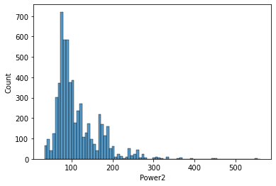

```python
sns.histplot(data=cars2, x='Power2')
```

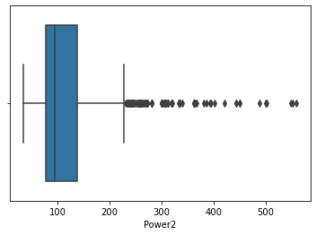

```python
sns.boxplot(data=cars2, x='Power2')
```

### Power has a skewed right distribution therefore outliers appear to be reasonable for the distribution and problem domain.

## Model Build (Using code from Anime Notebook)

```python
#Split data into 70% train and 30%  test
from sklearn.model_selection import train_test_split

x_train, x_test, y_train, y_test = train_test_split(X, y, test_size=0.3, random_state=1)
```

```python
# Verify the number of rows for training and testing datasets
print("Number of rows in train data =", x_train.shape[0])
print("Number of rows in test data =", x_test.shape[0])
```

```
Number of rows in train data = 4212
Number of rows in test data = 1806
```

```python
# to build linear regression_model
from sklearn.linear_model import LinearRegression

# to check model performance
from sklearn.metrics import mean_absolute_error, mean_squared_error, r2_score
```

```python
lin_reg_model = LinearRegression()
lin_reg_model.fit(x_train, y_train)
```

```
LinearRegression()
```

```python
#Check Model Performance (using code from Anime Notebook)
# function to compute adjusted R-squared
def adj_r2_score(predictors, targets, predictions):
    r2 = r2_score(targets, predictions)
    n = predictors.shape[0]
    k = predictors.shape[1]
    return 1 - ((1 - r2) * (n - 1) / (n - k - 1))


# function to compute MAPE
def mape_score(targets, predictions):
    return np.mean(np.abs(targets - predictions) / targets) * 100


# function to compute different metrics to check performance of a regression model
def model_performance_regression(model, predictors, target):
    """
    Function to compute different metrics to check regression model performance

    model: regressor
    predictors: independent variables
    target: dependent variable
    """

    # predicting using the independent variables
    pred = model.predict(predictors)

    r2 = r2_score(target, pred)  # to compute R-squared
    adjr2 = adj_r2_score(predictors, target, pred)  # to compute adjusted R-squared
    rmse = np.sqrt(mean_squared_error(target, pred))  # to compute RMSE
    mae = mean_absolute_error(target, pred)  # to compute MAE
    mape = mape_score(target, pred)  # to compute MAPE

    # creating a dataframe of metrics
    df_perf = pd.DataFrame(
        {
            "RMSE": rmse,
            "MAE": mae,
            "R-squared": r2,
            "Adj. R-squared": adjr2,
            "MAPE": mape
        },
        index=[0],
    )

    return df_perf
```

```python
# Checking model performance on train set (using code from Anime notebook)
print("Training Performance\n")
lin_reg_model_train_perf = model_performance_regression(lin_reg_model, x_train, y_train)
lin_reg_model_train_perf
```

```
Training Performance
```

|  | RMSE | MAE | R-squared | Adj. R-squared | MAPE |
| --- | --- | --- | --- | --- | --- |
| 0 | 1.897497 | 0.943437 | 0.971156 | 0.94661 | 16.161095 |

```python
# Checking model performance on test set (using code from Anime notebook)
print("Test Performance\n")
lin_reg_model_test_perf = model_performance_regression(lin_reg_model, x_test, y_test)
lin_reg_model_test_perf
```

```
Test Performance
```

|  | RMSE | MAE | R-squared | Adj. R-squared | MAPE |
| --- | --- | --- | --- | --- | --- |
| 0 | 4.590205 | 2.161576 | 0.830369 | 3.337282 | 37.652324 |

## Model Performance (using Anime case study as a guide for evaluation)

MAE indicates that our current model is able to predict Price within a mean error of 0.2.16 on the test set. This is reasoanble for the dataset.

MAPE of 37.65 on the test data means that we are able to predict within ~38% of the used car price.

Overall the model could be improved by more feature engineering, that is eliminating certain independent variables are generating new models to see if the model can be improved. Additionally, many numical variables were scaled using log or MinMax scaling. Experimenting with various scales might improve the model. Finally, although outlier detection was performed on numeric variables, it was not investigated for categorical variables. This also might improve the model.

# Key Business Takeaways

The Linear Regression Model can be used as a predictor of used car prices given the following information about the car: Model Name, Brand Name, Location, Manufacturing year, Kilometers Drive, Fuel Type, Transmission, Owner, standard Mileage, Ownershp type, engine, power, Seats and New_Price. New_Price is the most informative variable for Price.

The business should focus on the variables of New_Price and Location, as well as cars with 5 seats (as these are by far the most popular cars. I would also recommend that the business focus of Diesel or Petrol cars with Manual transmission.